# Data visualization with ggplot2

Some of the contents of this document have been adapted from Wilke (2019).[Take a look](https://serialmentor.com/dataviz/) at the online version of the booko for further insights.

# Introduction

**Data visualization** is part art and part science. The challenge is to get the art right without getting the science wrong and vice versa. A data visualization first and foremost has to accurately **convey the data**. It must not mislead or distort. If one number is twice as large as another, but in the visualization they look to be about the same, then the visualization is wrong. At the same time, a data visualization should be **aesthetically pleasing**. Good visual presentations tend to enhance the message of the visualization. If a figure contains jarring colors, imbalanced visual elements, or other features that distract, then the viewer will find it harder to inspect the figure and interpret it correctly.

Scientists frequently (though not always!) know how to visualize data without being grossly misleading. However, they may not have a well developed sense of visual aesthetics, and they may inadvertently make visual choices that detract from their desired message. Designers, on the other hand, may prepare visualizations that look beautiful but play fast and loose with the data.

The book attempts to cover the key principles, methods, and concepts required to visualize data for publications, reports, or presentations. Because data visualization is a vast field, and in its broadest definition could include topics as varied as schematic technical drawings, 3D animations, and user interfaces, I necessarily had to limit my scope for this book. I am specifically covering the case of static visualizations presented in print, online, or as slides. The book does not cover interactive visuals or movies, except in one brief section in the chapter on visualizing uncertainty. Therefore, throughout this book, I will use the words “visualization” and “figure” somewhat interchangeably. The book also does not provide any instruction on *how* to make figures with existing visualization softwares or programming libraries. The annotated bibliography at the end of the book includes pointers to appropriate texts covering these topics.

## Ugly, bad, and wrong figures

Throughout this book, I frequently show different versions of the same figures, some as examples of how to make a good visualization and some as examples of how not to. To provide a simple visual guideline of which examples should be emulated and which should be avoided, I am clearly labeling problematic figures as “ugly”, “bad”, or “wrong”:

- **ugly**—A figure that has aesthetic problems but otherwise is clear and informative.
- **bad**—A figure that has problems related to perception; it may be unclear, confusing, overly complicated, or deceiving.
- **wrong**—A figure that has problems related to mathematics; it is objectively incorrect.

Examples of ugly, bad, and wrong figures. (a) A bar plot showing three values (A = 3, B = 5, and C = 4). This is a reasonable visualization with no major flaws. (b) An ugly version of part (a). While the plot is technically correct, it is not aesthetically pleasing. The colors are too bright and not useful. The background grid is too prominent. The text is displayed using three different fonts in three different sizes. (c) A bad version of part (a). Each bar is shown with its own *y*-axis scale. Because the scales don’t align, this makes the figure misleading. One can easily get the impression that the three values are closer together than they actually are. (d) A wrong version of part (a). Without an explicit *y* axis scale, the numbers represented by the bars cannot be ascertained. The bars appear to be of lengths 1, 3, and 2, even though the values displayed are meant to be 3, 5, and 4.

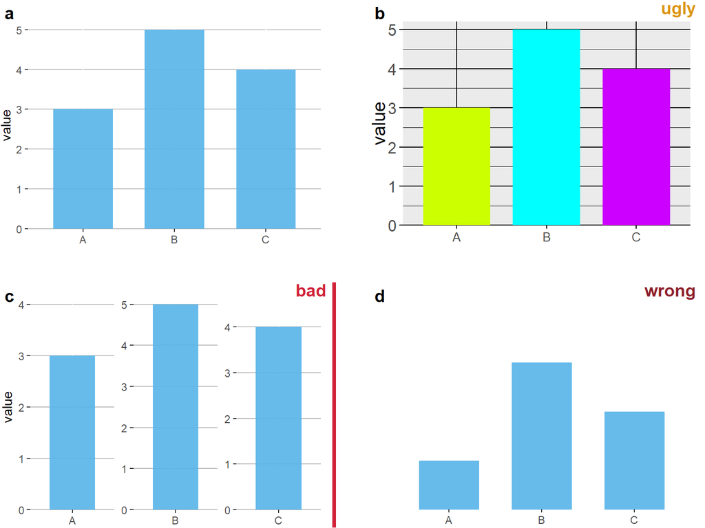

# Visualizing data: Mapping data onto aesthetics

> “The simple graph has brought more information to the data analyst’s mind than any other device.” — John Tukey

Whenever we visualize data, we take data values and convert them in a systematic and logical way into the visual elements that make up the final graphic. Even though there are many different types of data visualizations, and on first glance a scatter plot, a pie chart, and a heatmap don’t seem to have much in common, all these visualizations can be described with a common language that captures how data values are turned into blobs of ink on paper or colored pixels on screen. The key insight is the following: All data visualizations map data values into quantifiable features of the resulting graphic. We refer to these features as *aesthetics.*

## Aesthetics and types of data

Aesthetics describe every aspect of a given graphical element. A critical component of every graphical element is of course its *position,* which describes where the element is located. In standard 2d graphics, we describe positions by an *x* and *y* value, but other coordinate systems and one- or three-dimensional visualizations are possible. Next, all graphical elements have a *shape*, a *size*, and a *color.* Even if we are preparing a black-and-white drawing, graphical elements need to have a color to be visible, for example black if the background is white or white if the background is black. Finally, to the extent we are using lines to visualize data, these lines may have different widths or dash–dot patterns. Beyond this handful of examples, there are many other aesthetics we may encounter in a data visualization. For example, if we want to display text, we may have to specify font family, font face, and font size, and if graphical objects overlap, we may have to specify whether they are partially transparent.

Commonly used aesthetics in data visualization are position, shape, size, color, line width, line type. Some of these aesthetics can represent both continuous and discrete data (position, size, line width, color) while others can usually only represent discrete data (shape, line type).

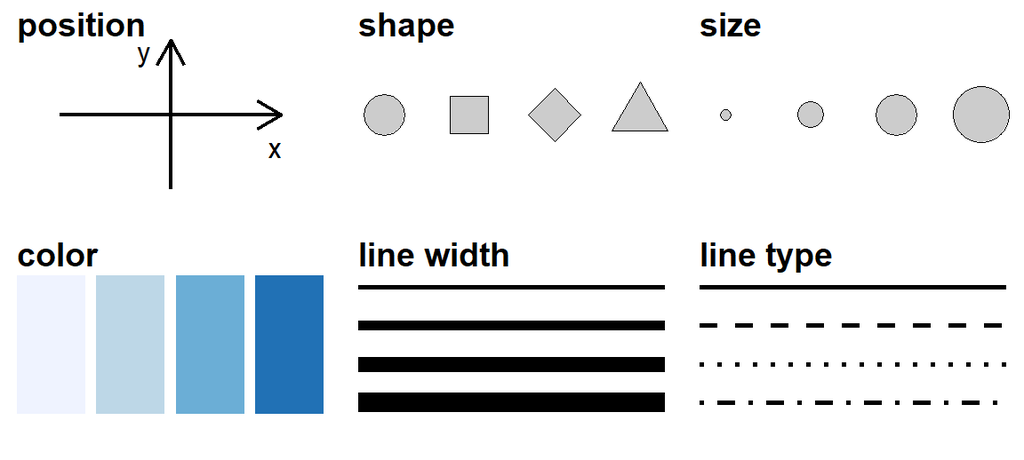

## Visualizing amounts

The most common approach to visualizing amounts (i.e., numerical values shown for some set of categories) is using bars, either vertically or horizontally arranged. However, instead of using bars, we can also place dots at the location where the corresponding bar would end.

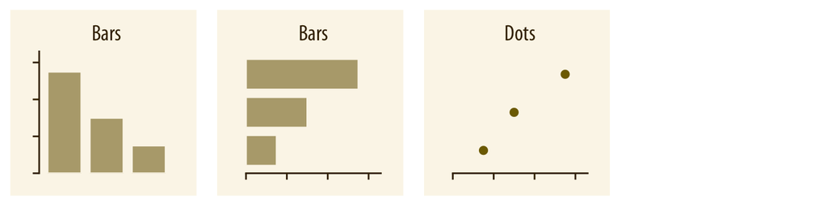

If there are two or more sets of categories for which we want to show amounts, we can group or stack the bars. We can also map the categories onto the *x* and *y* axis and show amounts by color, via a heatmap.

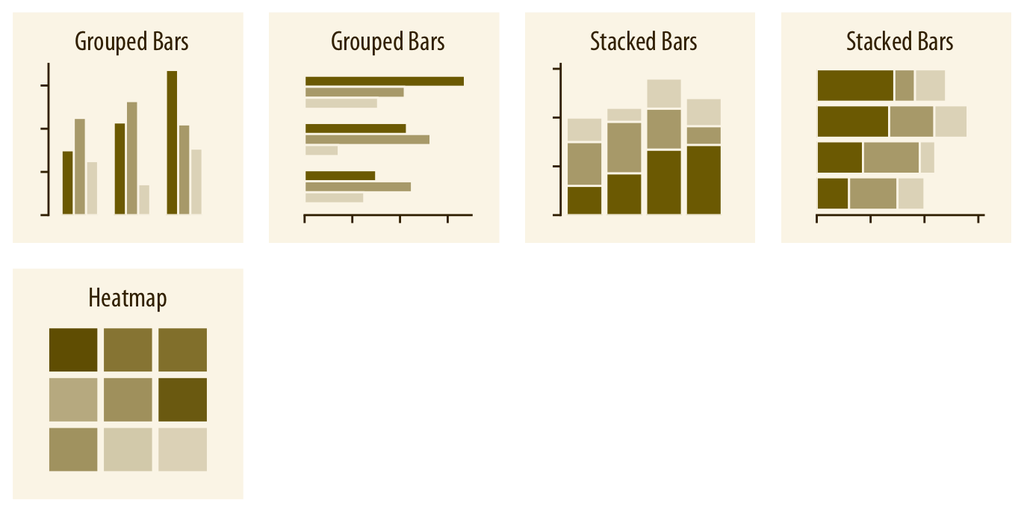

## Distributions

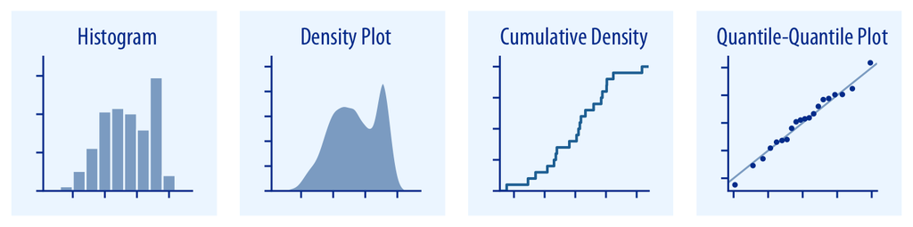

Boxplots, violins, strip charts, and sina plots are useful when we want to visualize many distributions at once and/or if we are primarily interested in overall shifts among the distributions . Stacked histograms and overlapping densities allow a more in-depth comparison of a smaller number of distributions, though stacked histograms can be difficult to interpret and are best avoided. Ridgeline plots can be a useful alternative to violin plots and are often useful when visualizing very large numbers of distributions or changes in distributions over time.

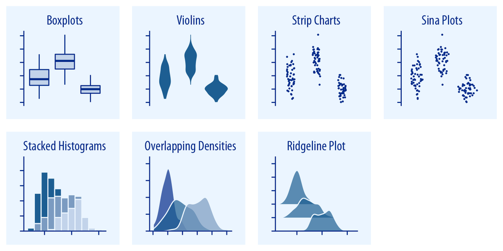

## Proportions

Proportions can be visualized as pie charts, side-by-side bars, or stacked bars, and as in the case for amounts, bars can be arranged either vertically or horizontally. Pie charts emphasize that the individual parts add up to a whole and highlight simple fractions. However, the individual pieces are more easily compared in side-by-side bars. Stacked bars look awkward for a single set of proportions, but can be useful when comparing multiple sets of proportions (see below).

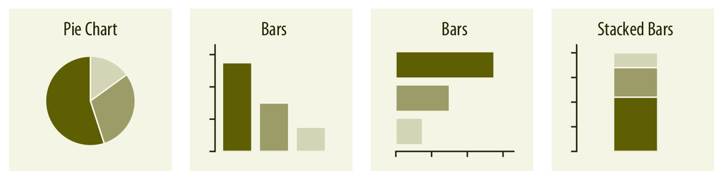

When visualizing multiple sets of proportions or changes in proportions across conditions, pie charts tend to be space-inefficient and often obscure relationships. Grouped bars work well as long as the number of conditions compared is moderate, and stacked bars can work for large numbers of conditions. Stacked densitiesare appropriate when the proportions change along a continuous variable.

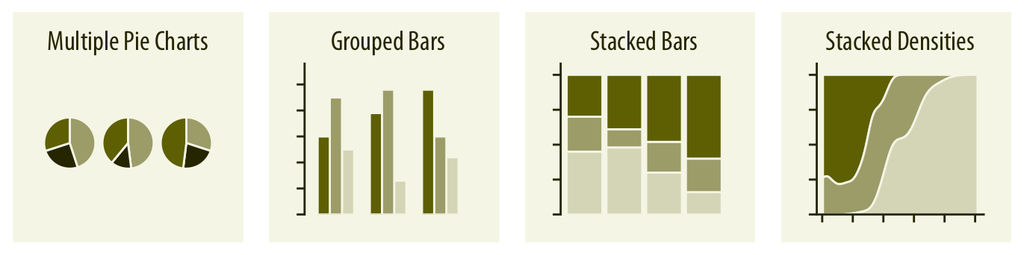

## *x*–*y* relationships

Scatterplots represent the archetypical visualization when we want to show one quantitative variable relative to another. If we have three quantitative variables, we can map one onto the dot size, creating a variant of the scatterplot called bubble chart. For paired data, where the variables along the *x* and the *y* axes are measured in the same units, it is generally helpful to add a line indicating *x* = *y*. Paired data can also be shown as a slope graph of paired points connected by straight lines.

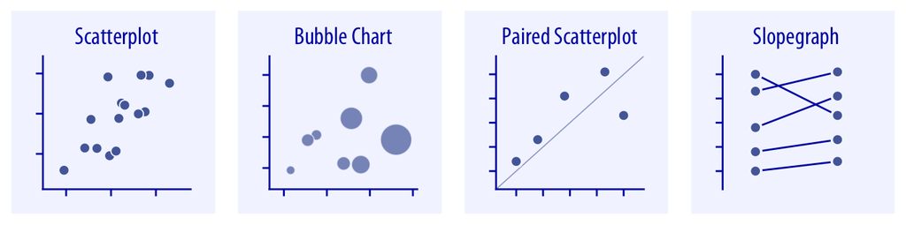

For large numbers of points, regular scatterplots can become uninformative due to overplotting. In this case, contour lines, 2D bins, or hex bins may provide an alternative. When we want to visualize more than two quantities, on the other hand, we may choose to plot correlation coefficients in the form of a correlogram instead of the underlying raw data.

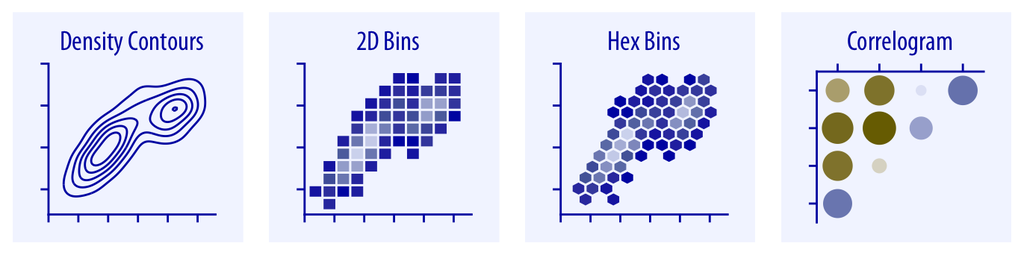

## Uncertainty

Error bars are meant to indicate the range of likely values for some estimate or measurement. They extend horizontally and/or vertically from some reference point representing the estimate or measurement. Reference points can be shown in various ways, such as by dots or by bars. Graded error bars show multiple ranges at the same time, where each range corresponds to a different degree of confidence. They are in effect multiple error bars with different line thicknesses plotted on top of each other.

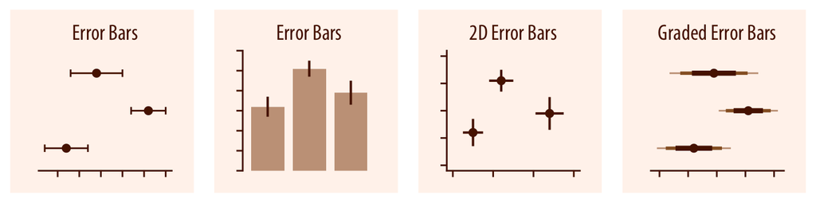

# What’s ggplot?

`ggplot2` is a package belonging to the tidyverse suite provinding a complete set of tools to visualize tidy data. `ggplot2`, is a graphing library in R that makes beautiful graphs, though its syntax can be formidably complex, with a somewhat steep learning curve.

That being said, learning ggplot2 is worth the effort for a couple of reasons. First, the graphs are beautiful. Second, ggplot2’s syntax, though seemingly arcane at times, forces you to think about the nature of your data, and the ideas that you are graphing. Lastly, a little bit of knowledge about ggplot2 can go a long way, and can build a powerful foundation for future learning.

## Why use ggplot2?

- Automatic legends, colors, etc.
- Easy superposition, facetting, etc.
- Nice rendering (yet, I don’t like the default grey theme).
- **Store any ggplot2 object for modification or future recall.**
- Lots of users (less bugs, much help on Stack Overflow).
- Lots of extensions.
- Nice saving option.

## Learning ggplot

There are 3 essential elements to any ggplot call:

1. An `aesthetic` that tells ggplot which variables are being mapped to the x axis, y axis, (and often other attributes of the graph, such as the color fill). Intuitively, the aesthetic can be thought of as what you are graphing.
2. A `geom` or geometry that tells ggplot about the basic structure of the graph. Intuitively, the geom can be thought of as how you are graphing
3. Other options, such as a graph title, axis labels and overall theme for the graph.

The basic syntax and elements of a ggplot call are something close to this:

```
ggplot(data = <DATA>) +
  <GEOM_FUNCTION>(
     mapping = aes(<MAPPINGS>),
     stat = <STAT>,
     position = <POSITION>
  ) +
  <COORDINATE_FUNCTION> +
  <FACET_FUNCTION>
```

Take a loof at the [reference guide](https://ggplot2.tidyverse.org/reference/) from the tidyverse site, visit the [sthda website](http://www.sthda.com/english/wiki/ggplot2-essentials) or check `ggplot2`’s cheatsheet:

[figure not shown]

## Pipelines and `ggplot2`

Since `ggplot2` it’s a member of tidyverse it was design to be operable from `dplyr`s pipelines. That means we can use any number of verbs to manipulate a data frame and then pass it to `ggplot()` using `%>%`. After that we keep using the regular `+` operator to concatenate plot instructions:

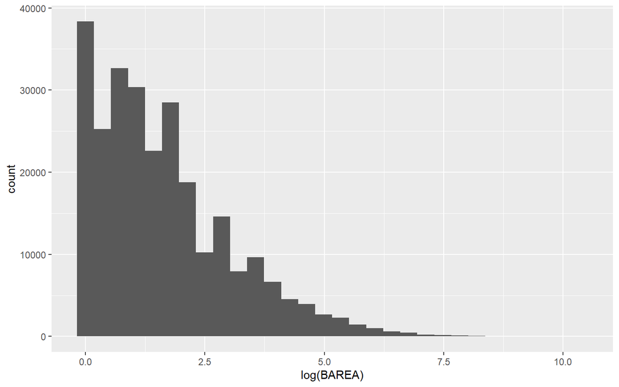

```r
fires %>%
  ggplot(aes(x=log(BAREA))) +
    geom_histogram()
```

## Basic plots with `ggplot2`

Before moving towards more fancy plots let’s cover the very basics of plotting and plot types:

- Histogram and density: `geom_histogram` and `geom_density`. Aesthetics just takes an `x` variable.
- Distributions: `geom_boxplot`. Aesthetics just takes an `y` variable.
- Line plots: and `geom_line`. They usually take both `x` and `y`.
- Bar plots: Similar to histograms but we must pass a `stat` argument:
- `identity`: take the raw value.
- `count`: frequency counts.
- Scatter plots: `geom_point`. used to draw relationships between two variables. They require both `x` and `y`.

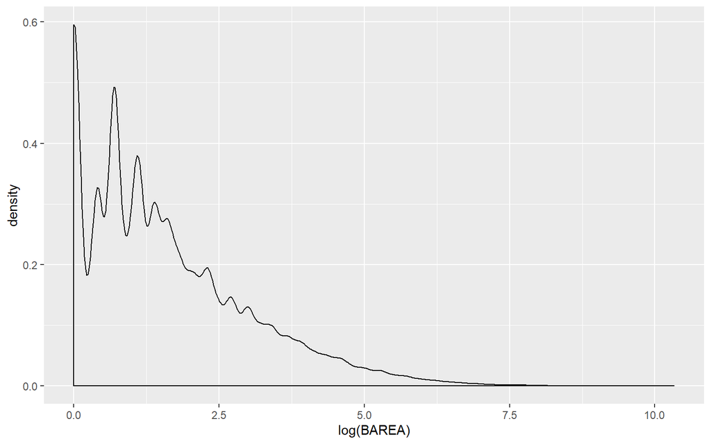

```r
fires %>%
  ggplot(aes(x=log(BAREA))) +
    geom_density()
```

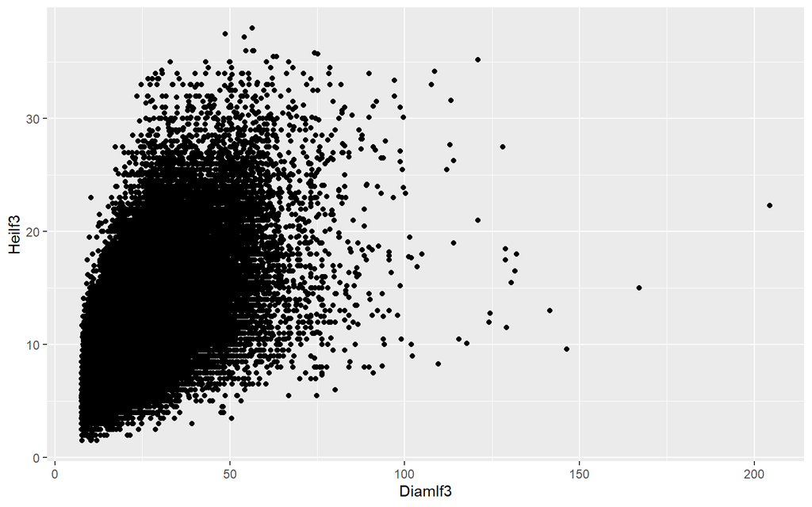

```r
trees %>%
  ggplot(aes(x=DiamIf3,y=HeiIf3)) +
    geom_point()
```

## Default themes

`ggplot2` offers several pre-set styling to rapidly amend the uglyness of the default settings:

- `theme_minimal`
- `theme_bw`
- `theme_light`
- `theme_grey`
- `theme_dark`

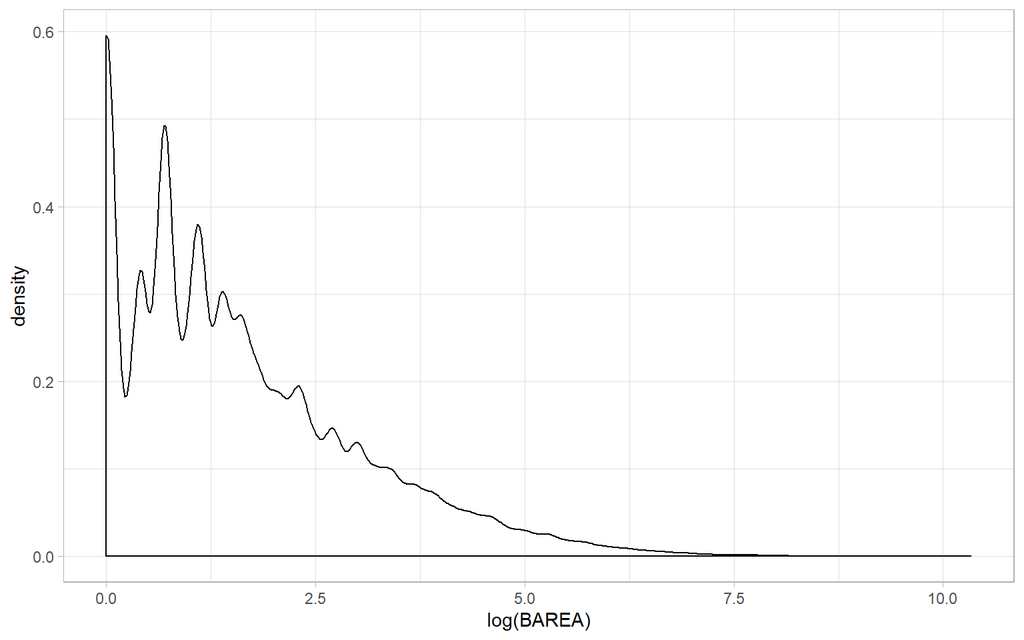

```r
fires %>%
  ggplot(aes(x=log(BAREA))) +
    geom_density()+
    theme_light()
```

**Exercise 1**

```
Try to apply the predefined themes in ggplot.
```

## Controlling the axis

We can adapt any element of a plot. Very often we will like to modify the limits of the x and y axis, the labels or the markers and ticks.

http://www.sthda.com/english/wiki/ggplot2-axis-scales-and-transformations

## Setting up our own theme

```r
newtheme <- theme_bw() +
  theme(panel.grid.major.x = element_blank(),
        panel.grid.minor.x = element_blank(),
        panel.background = element_rect(color='white'),
        axis.text.x = element_text(face = "bold",
                                   size = 7,
                                   vjust = 0.5,
                                   angle = 0))
```

**Exercise 2**

```
Take a look into the following plots. Try to reproduce them by running the code. Identify any potential issues and correct them in case there are any.
```

## Plotting time series

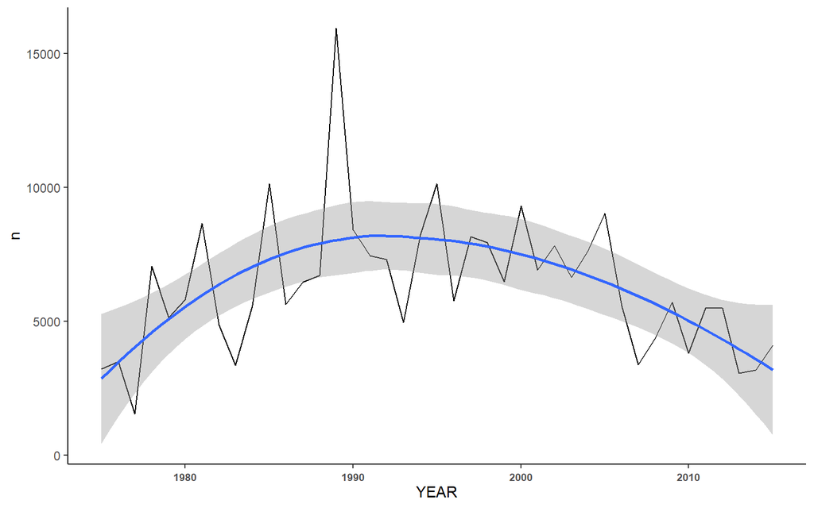

```r
fires %>%
  filter(BAREA>0,YEAR>1974) %>%
  group_by(YEAR) %>%
  summarise(n=n(),BA=sum(BAREA))%>%
  ggplot(aes(x=YEAR,y=n)) +
    geom_line() +
    geom_smooth() +
    newtheme +
    theme(axis.line = element_line(colour = "black"),
          panel.grid.major = element_blank(),
          panel.grid.minor = element_blank(),
          panel.border = element_blank(),
          panel.background = element_blank())
```

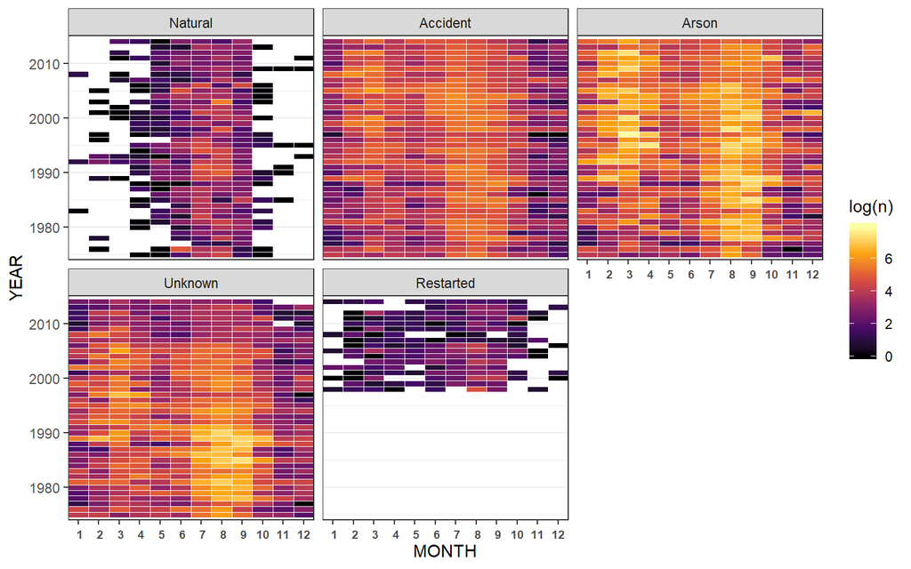

```r
fires$CAUSA.T <- fires$CAUSA
fires$CAUSA.T <-recode(fires$CAUSA.T, '1'= 'Natural','2'='Accident','3'='Accident','4'= 'Arson','5'='Unknown','6'='Restarted')
fires$CAUSA.T = factor(fires$CAUSA.T, levels=c('Natural','Accident',
                                               'Arson','Unknown','Restarted'))

fires %>%
  filter(YEAR>1974) %>%
  group_by(YEAR,MONTH,CAUSA.T) %>%
  summarise(n=n()) %>%
  ggplot(aes(y=YEAR,x=factor(MONTH),fill=log(n))) +
  geom_tile(color="white") +
  scale_x_discrete(name='MONTH',limits = c(1:12), expand = c(0, 0)) +
  scale_y_continuous(limits = c(1974,2015), expand = c(0, 0)) +
  scale_fill_viridis_c(option = 'B') +
  facet_wrap(~CAUSA.T) +
  newtheme
```

## Barplots

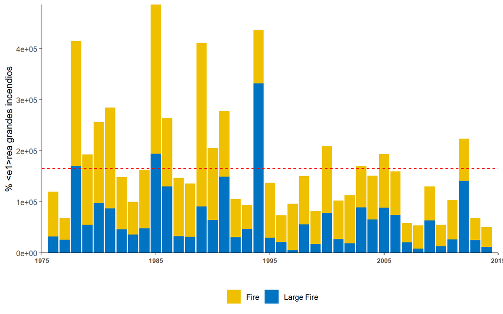

```r
ba.mean <- as.numeric(fires %>%
  group_by(YEAR) %>%
  summarise(BA=sum(BAREA))%>%
  summarise(mean(BA)))

fires %>%
  filter(YEAR>1974) %>%
  mutate(LARGE = ifelse(BAREA>500,"Large Fire","Fire")) %>%
  group_by(YEAR,LARGE) %>%
  summarise(n=n(),BA=sum(BAREA)) %>%
  ggplot(aes(x=YEAR,y=BA,group=LARGE,fill=LARGE)) +
    geom_bar(stat = 'identity') +
    scale_fill_manual(name='',
                      values = c('Fire'= '#EFC000FF','Large Fire'='#0073C2FF')) +
    scale_y_continuous(expand = c(0, 0)) +
    scale_x_continuous(limits = c(1975,2015), expand = c(0, 0)) +
    labs(x='',y='% æ¼ã¸±rea grandes incendios') +
    geom_hline(yintercept = ba.mean,col = "red",lty=2) +
    newtheme +
    theme(legend.position='bottom',
          axis.line = element_line(colour = "black"),
          panel.grid.major = element_blank(),
          panel.grid.minor = element_blank(),
          panel.border = element_blank(),
          panel.background = element_blank())
```

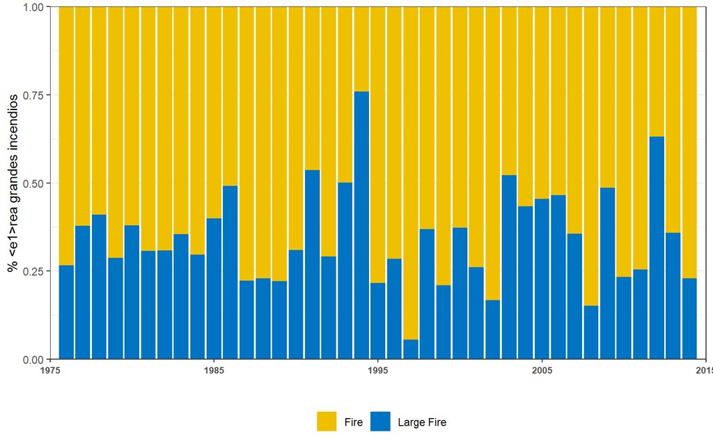

```r
fires %>%
  filter(YEAR>1974) %>%
  mutate(LARGE = ifelse(BAREA>500,"Large Fire","Fire")) %>%
  group_by(YEAR,LARGE) %>%
  summarise(n=n(),BA=sum(BAREA)) %>%
  mutate(fracc = BA / sum(BA)) %>%
  ggplot(aes(x=YEAR,y=fracc,group=LARGE,fill=LARGE)) +
    geom_bar(stat = 'identity') +
    scale_fill_manual(name='',
                      values = c('Fire'= '#EFC000FF','Large Fire'='#0073C2FF')) +
    scale_y_continuous(expand = c(0, 0)) +
    scale_x_continuous(limits = c(1975,2015), expand = c(0, 0)) +
    labs(x='',y='% æ¼ã¸±rea grandes incendios') +
    newtheme +
    theme(legend.position = 'bottom')
```

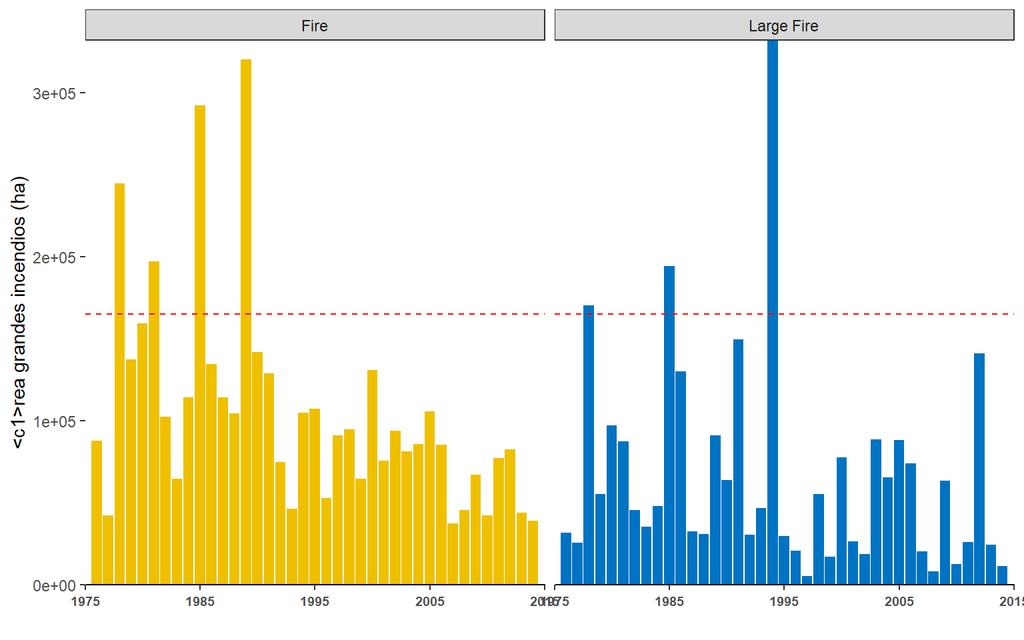

```r
fires %>%
  filter(YEAR>1974) %>%
  mutate(LARGE = ifelse(BAREA>500,"Large Fire","Fire")) %>%
  group_by(YEAR,LARGE) %>%
  summarise(n=n(),BA=sum(BAREA)) %>%
  ggplot(aes(x=YEAR,y=BA,group=LARGE,fill=LARGE)) +
  geom_bar(stat = 'identity') +
  scale_fill_manual(name='',
                    values = c('Fire'= '#EFC000FF','Large Fire'='#0073C2FF')) +
  scale_y_continuous(expand = c(0, 0)) +
  scale_x_continuous(limits = c(1975,2015), expand = c(0, 0)) +
  labs(x='',y='æ¼ã¸±rea grandes incendios (ha)') +
  geom_hline(yintercept = ba.mean,col = "red",lty=2) +
  facet_wrap(~LARGE) +
  newtheme +
  theme(legend.position='none',
        axis.line.x = element_line(colour = "black"),
        panel.grid.major = element_blank(),
        panel.grid.minor = element_blank(),
        panel.border = element_blank(),
        panel.background = element_blank())
```

## Donut and pie plots

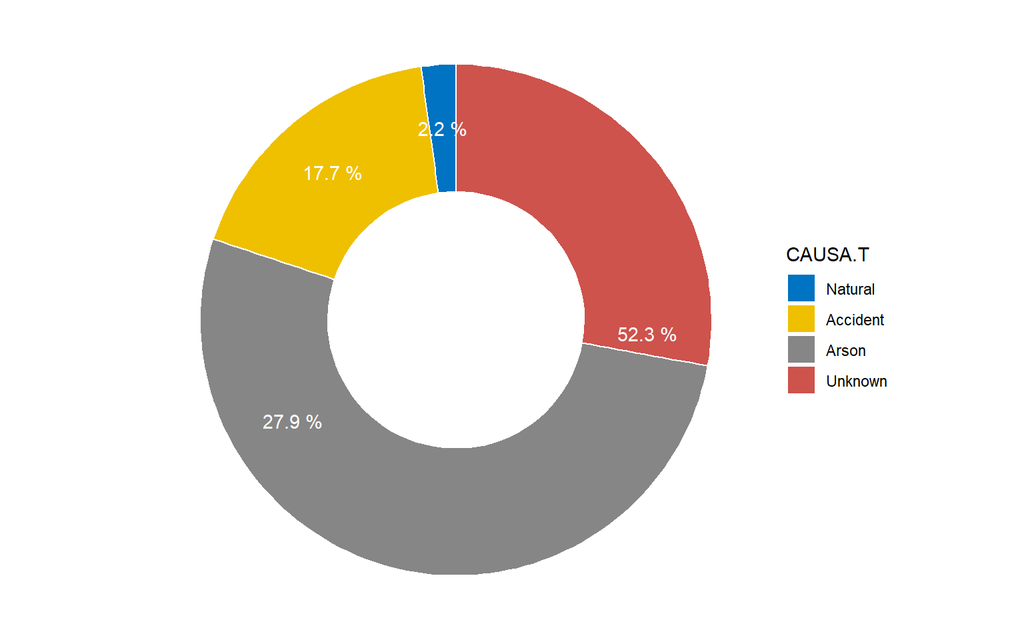

```r
mycols <- c("#0073C2FF", "#EFC000FF", "#868686FF", "#CD534CFF")

fires %>%
  filter(CAUSA!=6)%>%
  group_by(CAUSA.T) %>%
  summarise(n=n(),BA=sum(BAREA)) %>%
  mutate(f=round(n/sum(n)*100,1)) %>%
  arrange(desc(f)) %>%
  mutate(lab.ypos = cumsum(f) - 0.5*f)%>%
  ggplot(aes(x=2 ,y=f, fill=CAUSA.T))+
    geom_bar(width = 1, stat = "identity", color = "white") +
    coord_polar("y", start = 0)+
    geom_text(aes(y = lab.ypos, label = paste(f,'%')), color = "white")+
    scale_fill_manual(values = mycols) +
    theme_void()+
  xlim(0.5, 2.5)
```

## Scatter plots

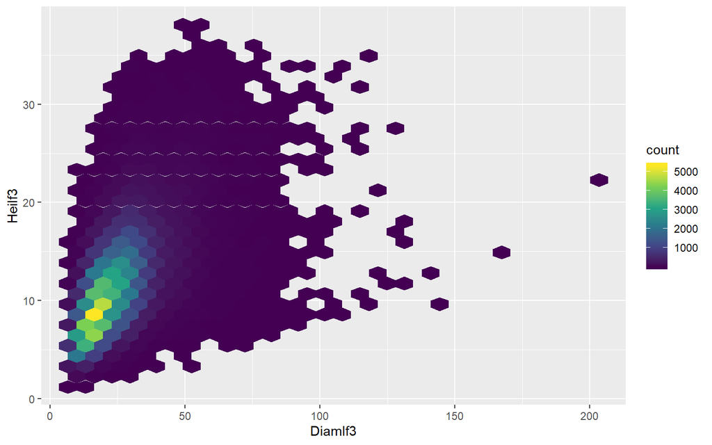

```r
trees %>%
  ggplot(aes(x=DiamIf3,y=HeiIf3)) +
  geom_hex() +
  scale_fill_viridis_c()
```

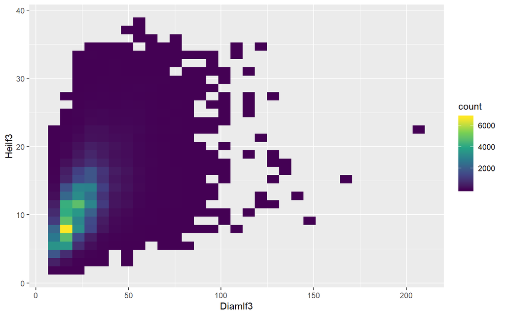

```r
trees %>%
  ggplot(aes(x=DiamIf3,y=HeiIf3)) +
  stat_bin2d() +
  scale_fill_viridis_c()
```

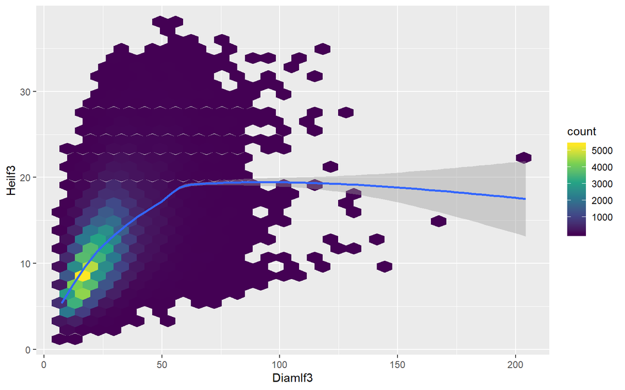

```r
trees %>%
  ggplot(aes(x=DiamIf3,y=HeiIf3)) +
  geom_hex() +
  scale_fill_viridis_c()+
  geom_smooth()
```

Wilke, C.O. 2019. *Fundamentals of Data Visualization: A Primer on Making Informative and Compelling Figures*. O’Reilly Media, Incorporated. https://books.google.es/books?id=L3ajtgEACAAJ.

Marcos Rodrigues

2020/02/03